# Exam exercise: Seasonal wind speed

It is highly recommended that you answer the exam using Rmarkdown (you can simply use the exam Rmarkdown file as a starting point).

The data set for this exam problem contains measurements of the quarterly average wind speed in the years 2001-2019. The measurements were made at the Danish weather station Sjælsmark in the years 2001-2019.

We first read in the data:

```r
library(mosaic)
wind <- read.delim("https://asta.math.aau.dk/datasets?file=speed_quarterly.txt",sep="")
head(wind)
```

```
##   quarter    speed
## 1  winter 3.571196
## 2  winter 4.448287
## 3  winter 3.590417
## 4  winter 3.306593
## 5  winter 4.047176
## 6  winter 3.395046
```

We saw in Exam exercise 1 that wind speed measurements are Weibull distributed. However, because of the central limit theorem, when we take the average of hourly measurements from three months, these values will be close to having a normal distribution. Hence, we will assume in this workshop that the quarterly averages are normally distributed.

Throughout the exercise, we use a significance level of $\alpha=0.05.$

# Part I: Comparison of wind speed for spring and autumn

In part I we compare the wind speed in spring and autumn. The questions for Part I should be answered using pen and paper. You may use R as a calculator. You can use the output from `favstats` in your computations:

```r
favstats(~speed|quarter,data=wind)
```

```
##   quarter      min       Q1   median       Q3      max     mean        sd  n
## 1  autumn 2.397207 3.010508 3.097482 3.230105 3.627427 3.094134 0.2532494 19
## 2  spring 2.877559 3.117040 3.380616 3.572803 3.794384 3.346272 0.2772962 19
## 3  summer 2.246513 2.699706 2.848324 3.059420 3.438134 2.878752 0.2751879 19
## 4  winter 2.940046 3.382014 3.805370 4.069144 4.448287 3.721420 0.4084774 19
##   missing
## 1       0
## 2       0
## 3       0
## 4       0
```

For independant random samples of sizes n1 and n2, respectively, from two populations, the f-value for testing variance1 = variance 2 is f = s1^2 / s2^2

```r
S_1 <- 0.2772962
S_2 <- 0.2532494
f_Test <- (S_1^2)/(S_2^2)
f_Test
```

```
## [1] 1.198922
```

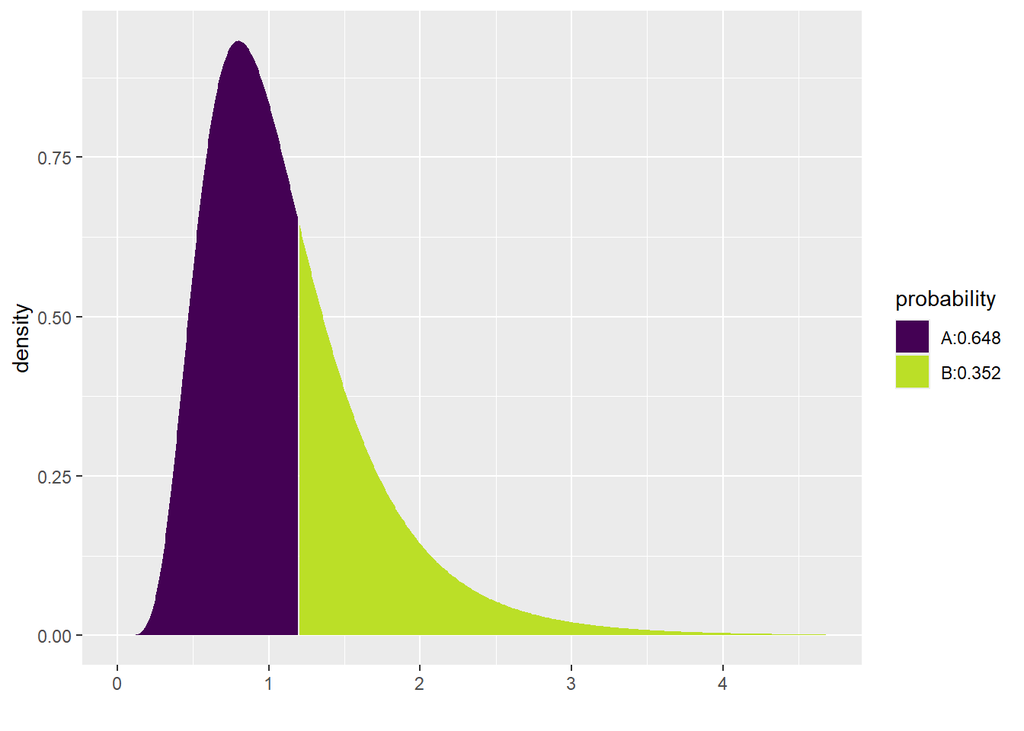

```
## [1] 0.6477654
```

```r
pdist("f", f_Test, df1=18, df2 = 18)
```

We have a two-sided tail test, where to total area of error must be 0.05, or 0.025 at each tail. Here we observe that 64.8% of observations would result in the variances being equal. this is far above the 2.5% region of error and thus we do not have enough evidance to support that they are not the same, we cannot reject H0.

1. Make an $F$-test to check whether the variance is the same in spring and autumn. See above.
2. Make a t-test to compare the mean wind speed in spring and autumn. What is the null hypothesis and the corresponding alternative hypothesis? Explain how the test statistic and p-value are computed? What is the conclusion of the analysis?

H0: mean1 = mean2 H1: mean1 != mean2 Under the assumption that the variances are equal, as by excercise one, we use the unknown bu equal variance test. We have a two-sided tail test, can accept +/- 2.5% error.

The two sample t-test is given as: $t = \frac{(\bar{x_1} - \bar{x_2})-d_0}{sp \cdot \sqrt{(1/n_1) + (1/n_2)}}$ $sp^2 = \frac{s_1^2(n_1-1)+s_2^2(n_2-1)}{n_1+n_2-2}$ Note that H0 defines the two true means to be equal such that d0 = 0. So, given that we observe xBar1 and xBar2, how likely is this observation if the true means µ1 and µ2 are equal.

```r
xBar1 <- 3.34627
xBar2 <- 3.09413
n_1 <- 19
n_2 <- 19
S_1
```

```
## [1] 0.2772962
```

```r
S_2
```

```
## [1] 0.2532494
```

```r
sp <- (((S_1)^2)*((n_1)-1)+((S_2)^2)*((n_2)-1))/((n_1)+(n_2)-2)
sp <- sqrt(sp)
sp
```

```
## [1] 0.2655451
```

```r
do <- 0
t <- ((xBar1) -( xBar2) - do)/ (sp*sqrt((1/(n_1))+(1/(n_2))))
t
```

```
## [1] 2.926612
```

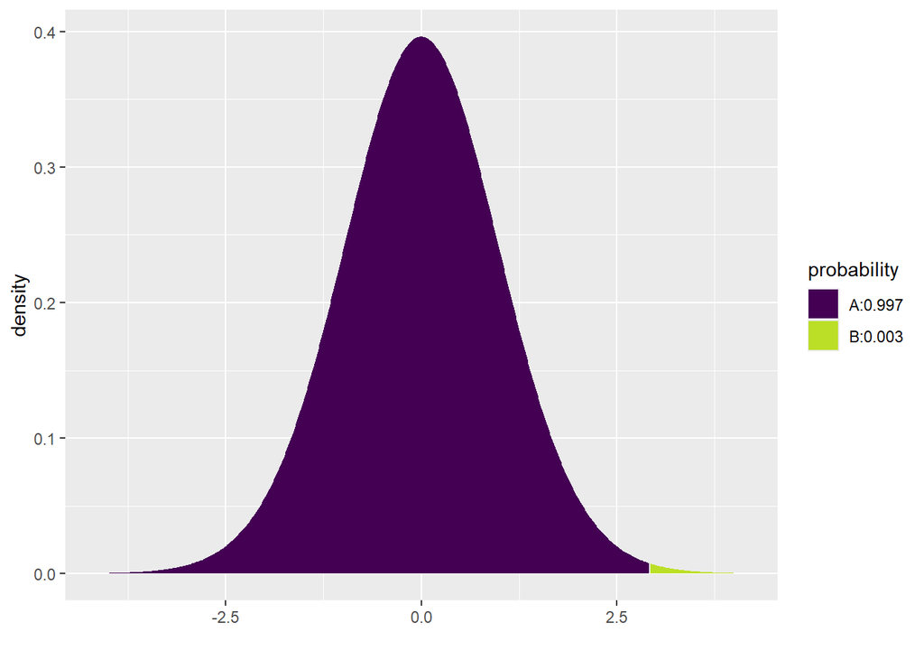

```
## [1] 0.9970488
```

```r
pdist("t", 2.9267, df=(n_1)+(n_2)-2)
```

Given, that the true means µ1 and µ2 are equal, the likelihood of observing t=2.93 or greater is only 0.3%, it is highly unlikely to have such an observation of µ1 and µ2 being equal, given the variances that was observed.

3. Make a 95% confidence interval for the difference between mean wind speed in spring and autumn. What is the interpretation of the confidence interval? There is a straight forward way of doing this, we shal first find the t_crit value for 2.5% as we have +/- 2.5% yielding a total confidance of 95% t value for v=30 is 2.042 t value for v=40 is 2.021 their average approximates that of v = 35, t $\approx 2.032$ The degrees of freedrom is given as $v= n_1+n_2-2$. $t_{a/2} \approx 2.032$

first we find the upper bound, as we already found the pooled standard deviation.

```r
print(xBar1-xBar2 + 2.032*sp*sqrt((1/(n_1))+(1/(n_2))))
```

```
## [1] 0.4272054
```

```r
print(xBar1-xBar2 - 2.032*sp*sqrt((1/(n_1))+(1/(n_2))))
```

```
## [1] 0.07707463
```

We can then say the following: $0.0771 < µ_1 - µ_2 < 0.4272$ The equation used for this is: ${\bar{x_1} - \bar{x_2} -t_{\alpha /2}\cdot \sqrt{1/n_1 + 1/n_2} < µ_1 - µ_2 < \bar{x_1} - \bar{x_2} +t_{\alpha /2}\cdot \sqrt{1/n_1 + 1/n_2}}$

$v = n_1 +n_2 -2$

## Part II: Comparing all four quarters

In this part we compare all four quarters of the year.

1. Make a box plot of the variable `speed` for each quarter and explain how a boxplot is computed.

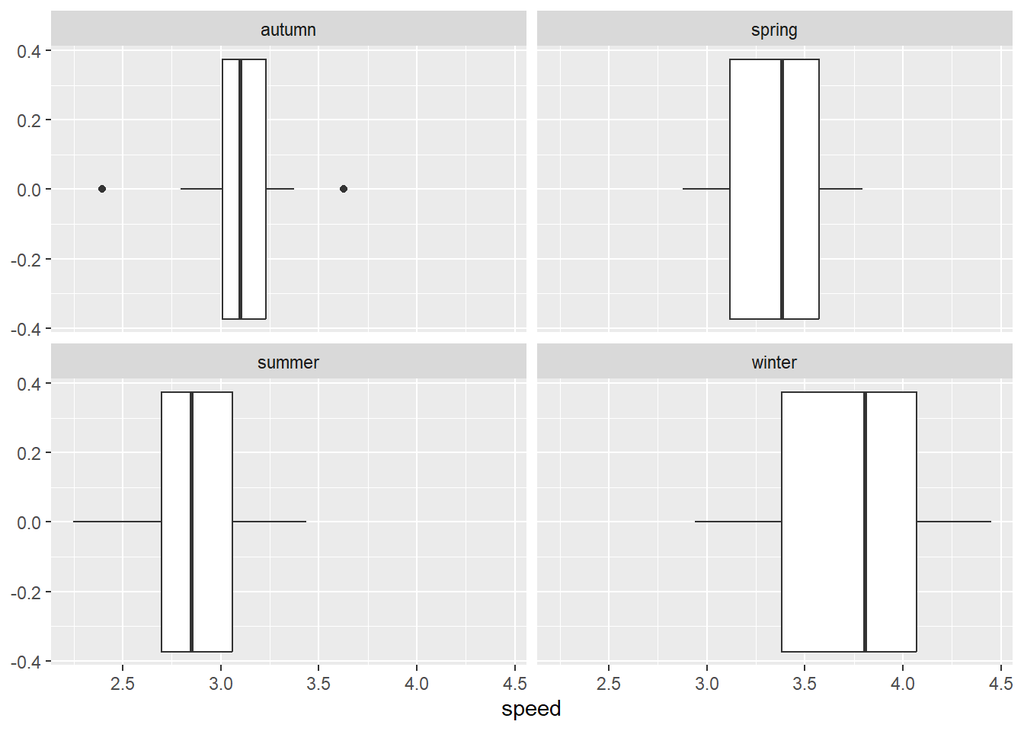

```r
gf_boxplot(~speed|quarter,data=wind)
```

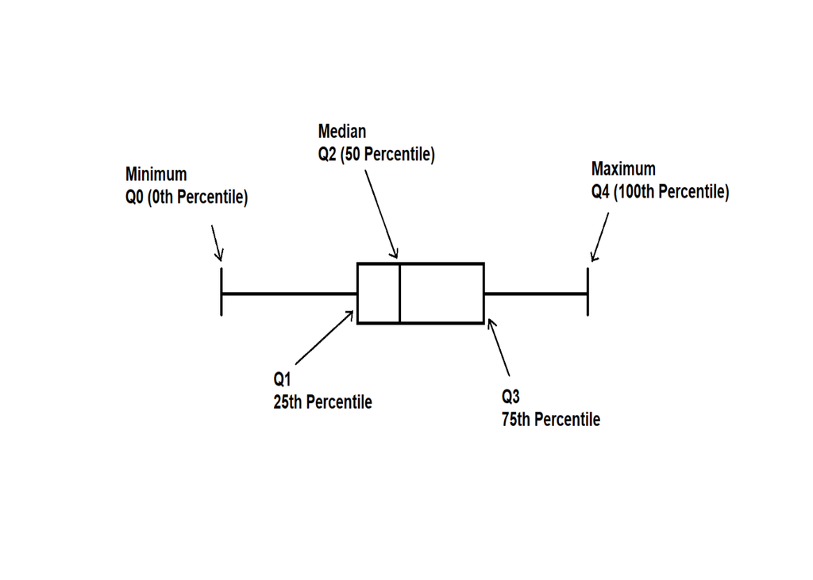

```r
library("png")
pp <- readPNG("Median_JFT.png")
plot.new()
rasterImage(pp,0,0,1,1)
```

A boxplot can be constructed as showen in the figure above. Where Q0 or the minimum bar marks the minima of the dataseet excluding any outliers. Q1 marks the 25th percentile, it is also the median of the lower half of the dataset. Q2 is the median of the dataset, it is the value ocuring most often. Q3 is the 75th perventile, 75% off all “samples” lies from Q0 to Q3, this is also the median of the upper half of the dataset. Q4 is the maxima of the dataset, excluding outliers

2. Test the null-hypothesis that the mean wind speed is the same for all four quarters by editing the code below. Explain the parameter estimates in the output.

```r
model <- lm(speed~quarter,data=wind)
summary(model)
```

```
##
## Call:
## lm(formula = speed ~ quarter, data = wind)
##
## Residuals:
##      Min       1Q   Median       3Q      Max
## -0.78137 -0.18743  0.01865  0.20684  0.72687
##
## Coefficients:
##               Estimate Std. Error t value Pr(>|t|)
## (Intercept)    3.09413    0.07105  43.551  < 2e-16 ***
## quarterspring  0.25214    0.10047   2.509   0.0143 *
## quartersummer -0.21538    0.10047  -2.144   0.0354 *
## quarterwinter  0.62729    0.10047   6.243 2.66e-08 ***
## ---
## Signif. codes:  0 '***' 0.001 '**' 0.01 '*' 0.05 '.' 0.1 ' ' 1
##
## Residual standard error: 0.3097 on 72 degrees of freedom
## Multiple R-squared:  0.5197, Adjusted R-squared:  0.4997
## F-statistic: 25.97 on 3 and 72 DF,  p-value: 1.711e-11
```

Using the lm function we get Fobs to 26, in other words if the true means of all seasons were the same, it would require us to hit a critical value of f=26 or above to observe such an extreme case, this is a probability of 1.7E-11. NOT HAPPENING.

To find out which quarters differ, we can make pairwise comparisons. We could use the pairwise t-tests as in Part I, Exercise 3. However, there is a problem with this approach:

3. How many pairwise comparisons of quarterly mean values can we make? What is the probability of rejecting a single true null-hypothesis? If we test several true null-hypotheses, explain why the probability of falsely rejecting at least one of them is larger than the significance level.

We can make 6 different caparisons between means. This can be found using the binomial coefficient: We have 4 elements (seasons) and two comparisons such that we get: $\binom{n}{r} = \frac{n!}{r!(n-r)!} \Rightarrow \binom{4}{2} = \frac{4!}{2!(2)!} = 6$ We can make 6 different comparisons, given a probability of error of 5% for each the final probability of making at least one error is 6*0.05 = 0.3 or 30%. If we do not care what comparison is at “fault” or erroneous, but only care if we make an error, then there is 5% chance at each comparison for an error, and this adds up to a total chance for an error to be 30%. We can say that the event for each comparison is mutually exclusive. This is also the reason why we can add their probabilities together. We can say that the sample space contains 6 independent events, each event is a comparison either being true or false.

The probability of rejecting a single true null-hyp is 5% given a level of significance of $\alpha = 0.05$.

This phenomenon is known as multiple testing. We can adjust the pairwise t-tests for multiple testing by performing a so-called Tukey’s test. It replaces the t-distribution by a different distribution (the studentized range distribution) that takes multiple testing into account.

4. Tukey’s test can be performed using the code below. Which quarters differ significantly?

```r
model<-aov(speed~quarter,data=wind)
TukeyHSD(model, conf.level=.95)
```

```
##   Tukey multiple comparisons of means
##     95% family-wise confidence level
##
## Fit: aov(formula = speed ~ quarter, data = wind)
##
## $quarter
##                     diff         lwr         upr     p adj
## spring-autumn  0.2521376 -0.01211513  0.51639024 0.0668933
## summer-autumn -0.2153825 -0.47963516  0.04887022 0.1492955
## winter-autumn  0.6272860  0.36303327  0.89153864 0.0000002
## summer-spring -0.4675200 -0.73177271 -0.20326734 0.0000843
## winter-spring  0.3751484  0.11089571  0.63940109 0.0020779
## winter-summer  0.8426684  0.57841573  1.10692111 0.0000000
```

We can see that the largest difference is summer and winter.

5. Compare the confidence interval for the difference between spring and autumn from Tukey’s test to the one you computed in Part I, Exercise 3. What is different? Tukey’s test indicate from -0.012 to 0.516 and we found on for $0.0771 < µ_1 - µ_2 < 0.4272$ Tukey’s test interval is larger than the one we found.